# Homework 06

Author

wenhao7

## Question 1: Compare KNN and logistic regression

Use breast-cancer.csv, which contains 569 cases from the [Wisconsin Diagnostic Breast Cancer dataset](https://archive.ics.uci.edu/dataset/17/breast%2Bcancer%2Bwisconsin%2Bdiagnostic). Predict `y` (1 for malignant and 0 for benign) using `mean_radius`, `mean_texture`, and `mean_smoothness`.

Set a random seed and randomly split the observations into 70% training and 30% test data. Use the same split for every model. Standardize the predictors using the training means and standard deviations, and apply the same transformations to the test data.

Fit ordinary logistic regression with an intercept and no penalty, and KNN with Euclidean distance, equal neighbor weights, and

$$k\in\{5,15,25,35,45\}.$$

Using the estimated probabilities for `y = 1` on the test data, plot all six ROC curves in one figure and report their AUC values. Which of the six fitted models do you prefer? Give a brief justification based on your results.

### Answer

I used seed **432506** and a stratified 70/30 random split, which gave 398 training observations and 171 test observations. I estimated the standardization parameters using only the training data.

```python
logistic_model = LogisticRegression(C=np.inf, solver="lbfgs", max_iter=10000)
logistic_model.fit(X_train_std, y_train)

q1_probabilities = {
    "Logistic regression": logistic_model.predict_proba(X_test_std)[:, 1]
}

for k in [5, 15, 25, 35, 45]:
    model = KNeighborsClassifier(
        n_neighbors=k,
        metric="euclidean",
        weights="uniform",
    )
    model.fit(X_train_std, y_train)
    q1_probabilities[f"{k}-NN"] = model.predict_proba(X_test_std)[:, 1]

q1_auc = {
    model_name: roc_auc_score(y_test, probabilities)
    for model_name, probabilities in q1_probabilities.items()
}

q1_auc_table = pd.DataFrame(
    {"model": q1_auc.keys(), "test AUC": q1_auc.values()}
)
display(q1_auc_table.style.format({"test AUC": "{:.6f}"}).hide(axis="index"))
```

| model | test AUC |
| --- | --- |
| Logistic regression | 0.974883 |
| 5-NN | 0.937062 |
| 15-NN | 0.972985 |
| 25-NN | 0.973934 |
| 35-NN | 0.977512 |
| 45-NN | 0.978972 |

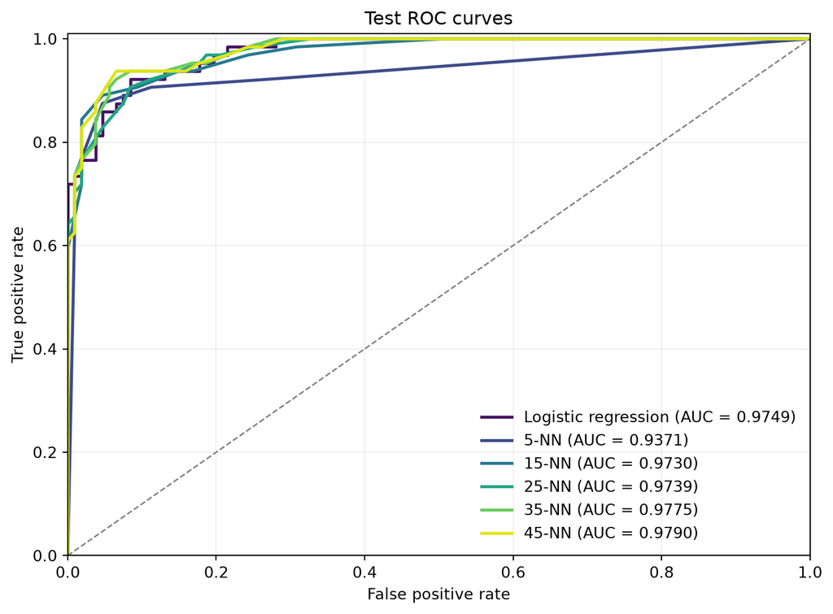

Figure 1: Test ROC curves for logistic regression and the five KNN models.

```python
fig, ax = plt.subplots(figsize=(7.5, 5.5), constrained_layout=True)
colors = plt.cm.viridis(np.linspace(0.05, 0.95, len(q1_probabilities)))

for (model_name, probabilities), color in zip(q1_probabilities.items(), colors):
    false_positive_rate, true_positive_rate, _ = roc_curve(y_test, probabilities)
    ax.plot(
        false_positive_rate,
        true_positive_rate,
        linewidth=2,
        color=color,
        label=f"{model_name} (AUC = {q1_auc[model_name]:.4f})",
    )

ax.plot([0, 1], [0, 1], color="gray", linestyle="--", linewidth=1)
ax.set_title("Test ROC curves")
ax.set_xlabel("False positive rate")
ax.set_ylabel("True positive rate")
ax.set_xlim(0, 1)
ax.set_ylim(0, 1.01)
ax.grid(alpha=0.2)
ax.legend(frameon=False, loc="lower right")
plt.show()
```

I prefer 45-NN among these fitted models because it has the largest test AUC, **0.978972**. Logistic regression is close, with an AUC of **0.974883**, so the observed advantage of 45-NN is small and should not be treated as a general result beyond this split.

## Question 2: Training and test ROC curves

Use the same data, training/test split, and standardization as in Question 1. Fit KNN with Euclidean distance, equal neighbor weights, and

$$k\in\{1,3,5,10,20\}.$$

Use each fitted model to estimate probabilities for both the training and test observations. For training predictions, include each observation itself among its $k$ nearest neighbors.

For each $k$, use a separate panel to show the training and test ROC curves together. Report both AUC values.

Explain the difference between training and test performance and how it changes with $k$. In particular, explain what happens at $k=1$ and why training performance may not reflect performance on new observations.

### Answer

```python
q2_k_values = [1, 3, 5, 10, 20]
q2_results = {}

for k in q2_k_values:
    model = KNeighborsClassifier(
        n_neighbors=k,
        metric="euclidean",
        weights="uniform",
    )
    model.fit(X_train_std, y_train)

    # Predicting on the training matrix includes each observation itself.
    train_probability = model.predict_proba(X_train_std)[:, 1]
    test_probability = model.predict_proba(X_test_std)[:, 1]
    q2_results[k] = {
        "train probability": train_probability,
        "test probability": test_probability,
        "train AUC": roc_auc_score(y_train, train_probability),
        "test AUC": roc_auc_score(y_test, test_probability),
    }

q2_auc_table = pd.DataFrame(
    [
        {
            "k": k,
            "training AUC": q2_results[k]["train AUC"],
            "test AUC": q2_results[k]["test AUC"],
        }
        for k in q2_k_values
    ]
)
display(
    q2_auc_table.style.format(
        {"training AUC": "{:.6f}", "test AUC": "{:.6f}"}
    ).hide(axis="index")
)
```

| k | training AUC | test AUC |
| --- | --- | --- |
| 1 | 1.000000 | 0.861127 |
| 3 | 0.992649 | 0.926548 |
| 5 | 0.987622 | 0.937062 |
| 10 | 0.983041 | 0.959623 |
| 20 | 0.981068 | 0.974372 |

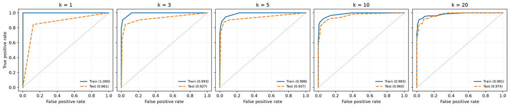

Figure 2: Training and test ROC curves for each value of k.

```python
fig, axes = plt.subplots(
    1, 5, figsize=(17, 3.5), sharex=True, sharey=True, constrained_layout=True
)

for ax, k in zip(axes, q2_k_values):
    train_fpr, train_tpr, _ = roc_curve(
        y_train, q2_results[k]["train probability"]
    )
    test_fpr, test_tpr, _ = roc_curve(
        y_test, q2_results[k]["test probability"]
    )
    ax.plot(
        train_fpr,
        train_tpr,
        linewidth=2,
        label=f"Train ({q2_results[k]['train AUC']:.3f})",
    )
    ax.plot(
        test_fpr,
        test_tpr,
        linewidth=2,
        linestyle="--",
        label=f"Test ({q2_results[k]['test AUC']:.3f})",
    )
    ax.plot([0, 1], [0, 1], color="gray", linestyle=":", linewidth=1)
    ax.set_title(f"k = {k}")
    ax.set_xlabel("False positive rate")
    ax.grid(alpha=0.2)
    ax.legend(frameon=False, fontsize=8, loc="lower right")

axes[0].set_ylabel("True positive rate")
plt.show()
```

Training AUC decreases from **1.000000** at $k=1$ to **0.981068** at $k=20$, while test AUC increases from **0.861127** to **0.974372** over the displayed values. The gap is especially large at $k=1$. Because each training observation is included among its own neighbors, its nearest neighbor is itself, so 1-NN assigns every training observation its own class and obtains perfect training performance. A new observation cannot use itself as a neighbor, so this perfect fit does not carry over to the test data. Increasing $k$ averages over a larger neighborhood, which reduces the model’s sensitivity to individual training observations and improves test performance in this split.

## Question 3: Peer evaluation of Homework 5

You will receive two Homework 5 submissions to review. The instructor’s GitHub account, **rqzhu-aide**, will open a **GitHub Issue** in the repository containing your Homework 5 submission. It will contain links to two other students’ repositories, where you can find their submitted homework reports.

Open your repository’s **Issues** tab on GitHub to find the assignment. You may ask AI to explain GitHub Issues or help you locate the assignment.

Choose **one specific mistake or item for improvement** from any question in either report.

1. **Identify the mistake or item for improvement.** State which report and question you selected, and briefly describe what is wrong or could be improved. Examples include incorrect code, a calculation error, a misinterpretation of results, a plot that could communicate the findings more clearly, or anything else you think could be done better.
2. **Explain your assessment.** Quote the relevant text, code, or figure caption exactly. Explain why the selected answer is incorrect or how it could be improved, referring to its reasoning, calculations, code, figures, or interpretation. **Complete this part yourself, without AI assistance.**
3. **Provide a correction.** Write a corrected or improved answer to the selected question, including any calculations, code, or figures needed.

After completing your review, **open a GitHub Issue in the repository containing the report you selected**. Identify the report and question, and include your assessment and a detailed revision plan explaining what the author should change and why. Include a link to your posted GitHub Issue in your Homework 6 answer.

### 1. Mistake selected

I reviewed **sophiastierwalt’s Homework 05, Question 4(c)**. The selected item is the calculation used to support the statement that Euclidean and Manhattan 5NN misclassified 11 of the same images. The filter does not calculate the intersection of the two methods’ error sets.

### 2. Assessment

```r
both = compare_manhattan_euc %>%
  filter(
    (pred_manhattan != pred_euclidean) &
    (pred_euclidean != y_test)
  )
```

> “Together, they misidentified 11 of the same photos.”

The first condition, `pred_manhattan != pred_euclidean`, means **the two distance metrics produced conflicting predictions (they disagree)**. The second condition, `pred_euclidean != y_test`, means **Euclidean distance misclassified the image**. However, the code **does not** directly check whether **Manhattan distance also got the prediction wrong (`pred_manhattan != y_test`)**. For example, consider a test image with true label **1**, Euclidean prediction **2**, and Manhattan prediction **1**. Under the original filtering condition, this observation **would** be selected because **Euclidean distance failed ($2 \neq 1$) and the two methods gave different results ($1 \neq 2$), even though Manhattan distance actually classified it correctly**. Therefore, the value 11 **cannot** be interpreted as **the total number of photos misclassified by both methods**. A more appropriate condition would need to check **`(pred_manhattan != y_test) & (pred_euclidean != y_test)`**

### 3. Correction and revision plan

The shared-error set should be calculated by requiring both predictions to differ from the true label:

```r
both_misclassified = compare_manhattan_euc %>%
  filter(
    (pred_manhattan != y_test) &
    (pred_euclidean != y_test)
  )

dim(both_misclassified)
# [1] 58  3
```

The corrected interpretation is: **Euclidean and Manhattan 5NN both misclassified 58 of the same test images.** They do not necessarily assign the same incorrect label to every shared error. The report should replace the disagreement condition with the two error conditions, report 58 instead of 11, and revise the surrounding sentence accordingly.

### GitHub Issue

Peer-review GitHub Issue: [Homework 05 Question 4(c) review](https://github.com/sophiastierwalt/stat432-fall2026/issues/3)